# Forecasting CMS Market Basket Using Discrete Time Series Methods (ARIMA)

Author

Ayesha Parsotan

Published

April 19, 2026

Presentation: slides.html

## Introduction

The Centers for Medicare and Medicaid Services (CMS) publishes market basket indices to measure the input price inflation healthcare providers can expect. These indices summarize expected changes in cost of labor, equipment, supplies, etc. required to deliver care and they stand as the standard for annual payment updates across major Medicare payment systems. Since Market Basket updates directly influence reimbursement levels, they play a central role in budgeting, actuarial modeling and financial planning throughout the healthcare industry. Organizations rely on these indices to anticipate future cost trends, evaluate financial risk and align internal expectations with federal payment policy Centers for Medicare & Medicaid Services (2025).

Within this broader framework, the Home Health market basket is particularly important. Under the Home Health Prospective Payment System (HH PPS), the market basket determines the annual payment update for home health agencies, affecting provider revenue, staffing capacity, and operational strategy. Although the final Home Health market basket update is published annually, CMS also releases quarterly projected index levels, creating a long historical times series that is suitable for statistical modeling.

Time‑series methods, particularly ARIMA models have been widely applied in healthcare economics to forecast medical expenditures, inflation, and service demand. Prior studies have demonstrated that ARIMA based approaches perform well in modeling healthcare spending and medical price behavior, including forecasting national health expenditures Dritsakis and Klazoglou (2019), providing broad overviews of health forecasting methodologies Soyiri and Reidpath (2013), and predicting medical service demand using hybrid ARIMA‑based models Huang et al. (2020). ARIMA models have also been used to forecast macroeconomic indicators in complex systems Vafin (2020), reinforcing their suitability for modeling structured economic indices such as the CMS market baskets. Foundational work on medical price indices further highlights the importance of understanding the time‑series properties of healthcare cost measures Berndt et al. (2000).

Forecasting the Home Health market basket can support financial planning, inform strategic decision‑making, and help organizations anticipate implications for cost‑of‑care management. This project applies classical time‑series methods to model and forecast the CMS Home Health Market Basket Index.

## Methods

A **Time Series** is a collection of observations $x_t$ made sequentially in time $T_0$. A somewhat unique feature of time series and their models is that we cannot assume that the observations arise independently from a common population. Studying models that incorporate dependence is the key concept in time series analysis Cryer and Chan (2010).

In general, the goal is to emphasize plotting methods that are appropriate and useful for finding patterns that will lead to suitable models for our time series data. Finding an appropriate model allows us to then forecast future values based on past-behavior.

There are three main steps in the process of finding an appropriate model.

1. Model Specification (Identification)
2. Model Fitting
3. Model Diagnostics

**Discrete-Time Series:** Observations are recorded at distinct, evenly spaced time point. Examples include: annual temperature, quarterly economic indicators.

**Continuous-Time Series:** Collection of observations that are made continuously over some time interval. For example: network traffic measured in real time.

The CMS Home Health Market Basket is observed quarterly, meaning the data occurs at fixed, evenly spaced intervals. Since the time series advances in discrete steps, all models evaluated in this study are formulated within a discrete time series stochastic process framework.

### Stationarity and Time Series Foundations

To make statistical inferences about the structure of a stochastic process on the basis of an observed record of that process, we must usually make some simplifying assumptions about the structure. The most important assumption is that of stationarity. The basic idea of stationarity is that that probability laws that govern behavior of the process do not change over time Cryer and Chan (2010).

A process $\{Y_t\}$ is strictly stationary if the joint distribution of $(Y_{t_1}, \ldots, Y_{t_n})$ is the same as the joint distribution of $(Y_{t_1-h}, \ldots, Y_{t_n-h})$ for all choices of time points $t_1,\ldots,t_n$ and all choices of time lag $h$.

$$f(Y_{t_1}, \ldots, Y_{t_n}) = f(Y_{t_1-h}, \ldots, Y_{t_n-h})$$

A process $\{Y_t\}$ is **weakly stationary** if it satisfies that following conditions:

Mean is constant:
$$E(Y_t) = \mu$$

Variance is constant: $Var(Y_t) = \sigma^2$

Autocovariance depends only on lag: $\gamma_{t,t-k} = \gamma_k$

Autocorrelation: $\gamma_{t,t-k} = \rho_k$

Weak stationarity is sufficient for ARMA and ARIMA models because they assume that the underlying statistical process is stable over time. However, most data sets are **non-Stationary**: without constant mean over time, and must be transformed.

$$X_t = \mu_t + Y_t, \\
\ where \ E(Y_t) = 0$$
$$\mu_t \text{ nonconstant } \;\Longrightarrow\; X_t \text{ is non-stationary}$$

After removing systematic components of a non-stationary series, the remaining series should resemble **white noise**: a sequence of independent, identically distributed random variables.

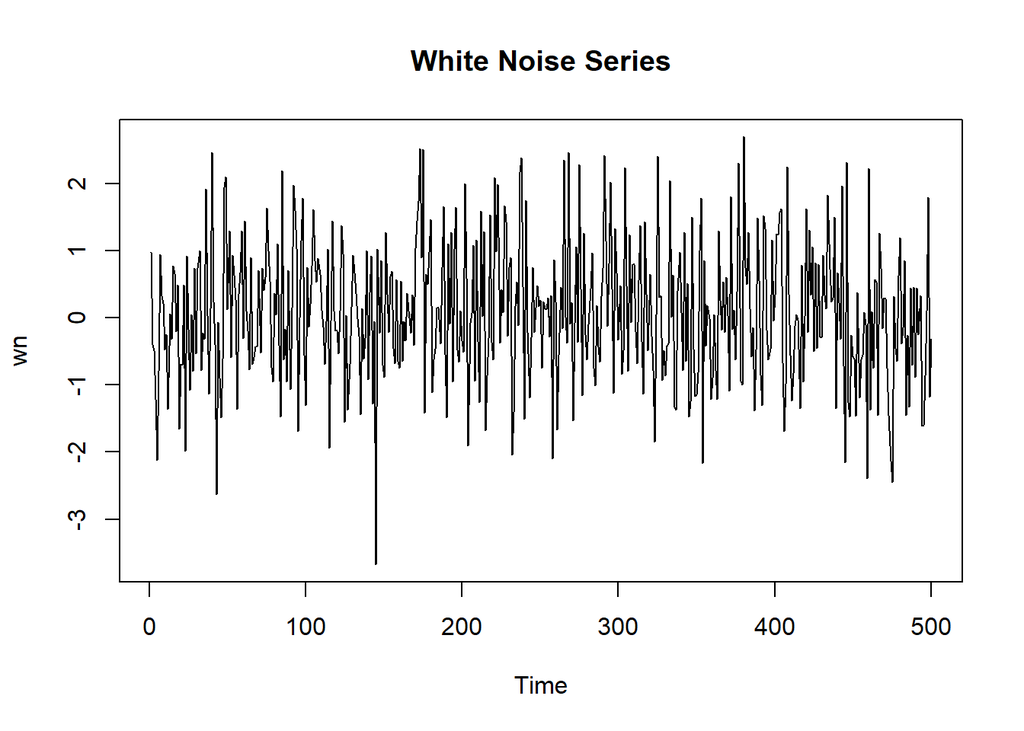

```r
wn <- rnorm(500)
plot.ts(wn, main = "White Noise Series")
```

In practice, stationarity is assessed using visual diagnostics and formal statistical tests before fitting time series models.

The **Augmented Dickey-Fuller (ADF)** test is used to assess stationarity.

$$H_0: \text{The series is NOT stationary} \quad\text{vs.}\quad H_1: \text{The series is stationary}$$

If the *p*-value is greater than 0.05, we will fail to reject $H_0$ and we can use trend or seasonal estimation/elimination methods, transform the times series data set and fit the non-stationary models.

**Trend:** a trend is a long term increase or decrease in the level of a time-series. It reflects persistent directional movement over time. Trends violate stationarity because the mean of the series changes over time. Differencing or de-trending is used to remove trend components.

A non-stationary trend implies: $E[x_t] \neq E[x_{t-k}]$

Trend differencing removes this component: $\nabla x_t = x_t - x_{t-1}$

**Periodicity** refers to any recurring pattern in the time series, regardless whether the cycle length is fixed or known. It indicates that the series contains repeating behavior, but the timing of the repetitions may vary.

**Seasonality** is a specific, structured form of periodicity where the cycle length is known, fixed and repeats at regular intervals.

$E[x_t] = E[x_{t-s}],\ \mathrm{Var}(x_t) = \mathrm{Var}(x_{t-s})$

All seasonal patterns are periodic, but not all periodic patterns are seasonal. Seasonal structure can be removed or modeled using seasonal differencing or SARIMA models, which incorporate seasonal autoregressive and moving-average components.

**Heteroskedasticity** occurs when the variance of the series changes over time. This violates the assumption of constant variance and can distort model estimation.

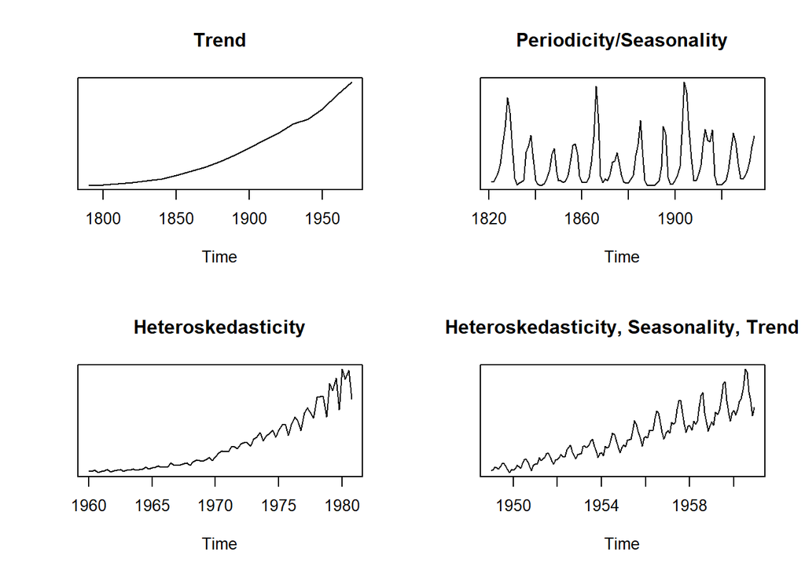

```r
par(mfrow =c(2,2))
data("uspop")
plot(uspop, ylab = "", yaxt = "n", main = "Trend")

data("lynx")
plot(lynx, ylab = "", yaxt = "n", main = "Periodicity/Seasonality")

data("JohnsonJohnson")
plot(JohnsonJohnson, ylab="",  yaxt = "n", main = "Heteroskedasticity")

data("AirPassengers")
plot(AirPassengers, ylab="",  yaxt = "n", main = "Heteroskedasticity, Seasonality, Trend")
```

### Models for Stationary and Non-Stationary Time Series

Let $Y_t$ denote the observed times series, and $e_t$ represent an unobserved white noise series. A **general linear process**, $Y_t$ is one that can represented as a weighted linear combination of present and past white noise terms as:

$$Y_t = \mu + \sum_{j=0}^{\infty} \psi_j e_{t-j}$$

where $\mu$ is a constant mean, $\{\psi_j\}$ is a sequence of coefficients, and $\{e_t\}$ is a white-noise innovation process.

**Stationary Models**

A **Moving Average (MA)** process of order *(q)*, written MA(*q),* models the current values of the series using the current error term and a finite number of past error terms. The standard form is:

$$Y_t = \mu - \theta_1 e_{t-1} - \cdots - \theta_q e_{t-q} + e_t$$

An **Autoregressive (AR)** process of order *(p)*, written AR*(p)*, expresses the current values of the series as a linear combination of its past values.

$$Y_t = \phi_1 y_{t-1} + \cdots + \phi_p y_{t-p} + e_t$$

An **Autoregressive Moving Average (ARMA)** model is appropriate for stationary time series. It combines AR terms: dependence on past values and MA terms: dependence on past shocks.

$$Y_t
= \phi_1 y_{t-1} + \cdots + \phi_p y_{t-p}
+ e_t
+ \theta_1 e_{t-1} + \cdots + \theta_q e_{t-q}.$$

**Non-Stationary Models**

An **Autoregressive Integrated Moving Average (ARIMA)** model is an extension of the ARMA model that incorporates non-seasonal differencing or detrending to remove trend and achieve stationarity.

$$\phi(B)(1-B)^d Y_t = \theta(B)e_t$$

**Differencing** or **de-trending** transforms a non-stationary series into a stationary one, allowing ARMA structure to be applied to the differenced data. ARIMA models are appropriate when the series shows trend but no seasonal pattern.

$$\nabla^{d} X_t = (1 - B)^{d} X_t$$

$$\nabla X_t = X_t - X_{t-1}$$

$$\tilde{Y}_t = X_t - (\hat{\beta}_0 + \hat{\beta}_1 t)$$

**Seasonal Autoregressive Integrated Moving Average** models extend the ARIMA framework to account for seasonal dependence in a time series. A SARIMA*(p,d,q)(P,D,Q)s* model includes both nonseasonal components *(p,d,q)* and seasonal components *(P,D,Q)* with seasonal period *s*.

The model is defined by applying both nonseasonal differencing *(1−B)d* and seasonal differencing *(1−Bs)D* to produce a stationary series.

A time series ${Yt}$ follows a SARIMA*(p,d,q)(P,D,Q)s* model if the differenced series is a stationary ARMA *(p,q)* process with additional seasonal AR and MA terms.

$$\phi(B)\,\Phi(B^s)\,(1-B)^d (1-B^s)^D Y_t
=
\theta(B)\,\Theta(B^s)\, e_t$$

### Model Specification (Identification)

In model specification, the classes of time series models are selected that may be appropriate for a given observed series. A model chosen at any time is tentative and subject to revision later on in the analysis. In choosing a model, we should attempt to adhere to the **principle of parsimony**; that is a model should require the smallest number of parameters that will adequately represent the time series Cryer and Chan (2010).

The **Autocorrelation Function (ACF)** measures the correlation between $x_t$ and its lagged values $x_t-{_k}$ :

$$\rho_k = \mathrm{Corr}(x_t, x_{t-k})$$

A sharp cutoff after lag q suggests an MA *(q)* component. A gradual, exponential decay suggests an AR or ARMA structure. Seasonal spikes at multiples of the seasonal period *s* indicate seasonal MA terms.

The **Partial Autocorrelation Function (PACF)** measures the correlation between $x_t$ and $x_t-{_k}$ after removing the effects of intermediate lags:

$$\phi_{kk} = \mathrm{Corr}(x_t, x_{t-k} \mid x_{t-1}, \ldots, x_{t-k+1})$$

A sharp cutoff after lag *p* suggests an AR*(p)* component. A gradual decay suggests an MA or ARMA structure. Seasonal PACF spikes at lag s indicate seasonal AR terms. A PACF is especially useful for identifying autoregressive behavior.

The **Extended Autocorrelation Function (EACF)** provides a systematic way to identify ARMA *(p,q)* orders when ACF and PACF patterns are ambiguous. The EACF constructs a grid where Rows = AR orders *p*, Columns = MA orders *q*. Each cell is marked as: “o” (model is plausible), “x” (model is not plausible). The grid is scanned for the first clean triangle of “o”, and the top left corner of the triangle gives ARMA*(p,q)* model. The EACF is especially valuable when ACF and PACF do not show clear cutoffs and the series has mixed AR and MA behavior.

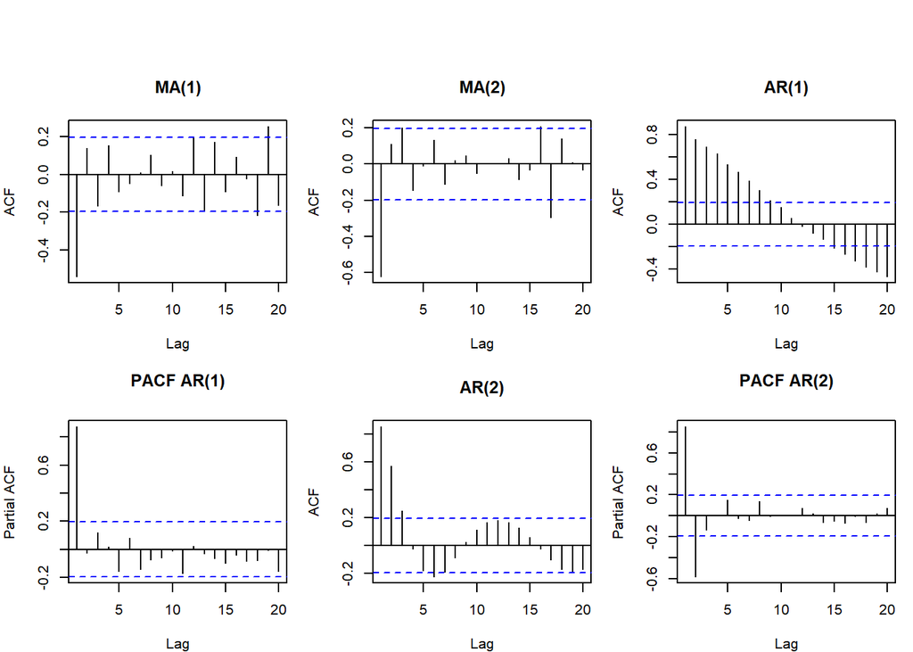

```r
ma1.1.s=arima.sim(list(order=c(0,0,1),ma=-0.9),100)
ma2.1.s=arima.sim(list(order=c(0,0,2),ma=c(-1,0.6)),100)
ar1.1.s=arima.sim(list(order=c(1,0,0),ar=0.9),100)
ar2.1.s=arima.sim(list(order=c(2,0,0),ar=c(1.5,-0.75)),100)
arma1.1.s=arima.sim(list(order=c(1,0,1),ar=0.6,ma=-0.3),100)

library(TSA)
par(mfrow = c(2, 3), oma = c(0, 0, 3, 0), mar = c(4, 4, 4, 1))
acf(ma1.1.s, main = "MA(1)")
acf(ma2.1.s, main = "MA(2)")
acf(ar1.1.s, main = "AR(1)")
pacf(ar1.1.s, main = "PACF AR(1)")
acf(ar2.1.s, main = "AR(2)")
pacf(ar2.1.s, main = "PACF AR(2)")
```

```r
eacf(arma1.1.s)
```

```
AR/MA
  0 1 2 3 4 5 6 7 8 9 10 11 12 13
0 x o o o o o o o o o o  o  o  o
1 x x o o o o o o o o o  o  o  o
2 x x o o o o o o o o o  o  o  o
3 x x o o o o o o o o o  o  o  o
4 x x o o o o o o o o o  o  o  o
5 o x o o o o o o o o o  o  o  o
6 o x o o x o o o o o o  o  o  o
7 o x o o x o o o o o o  o  o  o
```

After candidate models are manually identified, they are compared using the **Corrected Akaike Information Criterion (AICc):**

$$AIC_c = AIC + \frac{2k(k+1)}{n - k - 1}$$

where:

$$AIC = -2\log(L) + 2k$$

$L$ is the maximized likelihood,  
$k$ is the number of estimated parameters, and  
$n$ is the sample size.

AICc adjusts for small sample sized and prevents overfitting. A lower AICc equates to a better models, differences greater than 2 indicate meaningful improvement and the most adequate model is selected.

In addition to manual identification using ACF, PACF, EACF, this study uses **auto.arima()** function from the `forecast` package to support model selection. The auto.arima() function automatically determines, *p,d,q* and seasonal orders. It searches across candidate ARIMA/SARIMA models and selects the models with the lowest AICc. This function provides an objective benchmark, confirms or refines manually identified models and ensures the final model is optimal under AICc.

### Model Fitting (Parameter Estimation)

Once the model orders *(p,d,q)* have been identified, the next step is to estimate the parameters of the autoregressive (AR) , moving average (MA), and combined ARMA models. Parameter estimation determines the values of the AR co-effecient $\phi_i$ , the MA co-efficient $\theta_i$ and the innovation variance $\sigma^2$ . Different estimation methods apply depending on the model class.

1. *Yule-Walker Estimation | (AR)* : relate the AR coefficients to the autocovariance function.

   $$\gamma_k = \phi_1 \gamma_{k-1} + \cdots + \phi_p \gamma_{k-p},
   \qquad k = 1,\ldots,p.$$
2. *Burg Method | (AR)* : estimates AR parameters by minimizing forward and backward prediction errors while enforcing stability.
3. *Conditional Sum of Squares (CSS*) | *(AR, MA, ARMA)* : estimates AR and MA parameters by minimizing the sum of squared residuals. It is useful for initial parameters but less efficient than MLE

   $$\sum_{t = p+1}^{T} \varepsilon_t^2$$
4. *Maximum Likelihood Estimation (MLE) | (AR)* : maximizes the Gaussian likelihood, yielding efficient and asymptotically normal estimates. It is the preferred method for MA models because it accounts for the dependence on unobserved errors. This is required for the AICc model comparison and the model must pass the normality assumption for this estimation.

   $$L(\theta \mid y_1,\ldots,y_T),$$
5. *Innovations Algorithm | (MA)* : recursively computes optimal linear predictors and innovation variances, allowing estimation of MA parameters. It is efficient for pure MA models and handles missing data well.
6. *Hannan-Rissanen Method | (MA, ARMA)* : provides initial estimates for MA parameters, fits a higher order AR model to obtain pre-liminary residuals. This method regresses $Y_t$ on lagged values and estimated residuals and uses these as starting values for MLE. This method is widely used for ARMA models.

   *Summary of Parameter Estimation Methods*

   | **Model Type** | **Estimation Methods** | **Notes** |
   | --- | --- | --- |
   | AR *(p)* | Yule-Walker, Burg, CSS, MLE | Yule-Walker/Burg for initial estimates; MLE for refinement |
   | MA *(q)* | Innovations, Hannan-Rissanen, CSS, MLE | MA requires numerical methods; Hannan-Rissanen gives good starting values |
   | ARMA *(p,q)* | Hannan-Rissanen, CSS, MLE | Hannan-Risannen and MLE are standard |
   | ARIMA *(p,d,q)* | CSS, MLE |  |
   | SARIMA *(p,d,q)(P,D,Q)s* | CSS, MLE |  |

### Model Diagnostics

Model diagnostics focus on assessing how well a model fits the observed data and if the fit is inadequate, identifying suitable modifications. The main objective is to evaluate the adequacy of the selected model. After fitting the time series model, diagnostic checks on the residuals should be performed to evaluate the model’s fit. Residuals should behave like white noise and should exhibit no autocorrelation, constant variance, zero mean, approximate normality and no remaining seasonal structure.

**Statistical Inference for Model Coefficients**

Each estimated parameter is evaluated for statistical significance. For a generic coefficient $\beta$, the hypothesis test is:

$$H_0:\ \beta = 0 \quad\text{(coefficient is not significant)}$$

$$H_1:\ \beta \neq 0 \quad\text{(coefficient is significant)}$$

the test statistic is:

$$z = \frac{\hat{\beta}}{SE(\hat{\beta})}$$

and the corresponding p-value determines whether the coefficient is significant. If the *p*-value is less than 0.05, we reject $H_0$ and the coefficient is significant. Significant testing helps to identify parameter redundancy and prevents overfitting by ensuring that only meaningful terms are retained.

**Standardized Residuals:**

$$e_t^{*} = \frac{\hat{e}_t}{\hat{\sigma}}$$

residuals are examined to assess whether the model errors exhibit: zero mean, constant variance, no visible patterns, no remaining seasonality. A well fitted model produces residuals that fluctuate randomly around zero with no systematic structure.

**Normality Assessment:**

Approximate normality improves the reliability of forecast intervals. Normality was evaluated using Normal Q-Q plot, Shapiro-Wilk test and a histogram of standardized residuals. Extreme skewness or heavy tails may indicate the need for further transformation or alternative modeling.

**Residual ACF and PACF:**

The residual ACF was examined to detect remaining serial dependence. Significant spikes would indicate that the model failed to capture all AR or MA structure. For an adequate model, all residual autocorrelations lies within the 95% CI bounds, no seasonal spikes occur at lag and there is no slow decay or cyclical pattern.

The residual PACF of the residuals are also inspected. Significant spikes in the PACF suggest remaining autoregressive behavior. A well specified model should show no significant partial autocorrelations and no seasonal partial autocorrelations.

Together, the residual ACF and PACF confirm whether the model has removed all linear dependence.

**Ljung-Box Test:**

The Ljung-Box Test formally evaluates whether the residuals are uncorrelated:

$$\begin{aligned}
H_0:\ &\text{Residuals are white noise} \\
H_1:\ &\text{Residuals are not white noise}
\end{aligned}$$

A large *p*-value greater than 0.05 indicates failure to reject $H_0$ supporting the adequacy of the model.

### Forecasting

Forecasting in AR, MA, ARMA, ARIMA, SARIMA models is based on projecting the conditional expectation of future values given all information available up to time $T$:

This framework applies uniformly across all stationary and non-stationary models discussed. The goal of forecasting is to estimate future values of the series $Y_{T+h}$ for $h \ge 1$

while quantifying the uncertainty associated with those estimates.

The terms predicting and forecasting are often used interchangeable, however they have distinct meanings in time-series analysis. Prediction refers to estimating an unknown value within the observed sample and does not require temporal ordering. Forecasting refers specifically to estimating values beyond the end of the observed sample, using temporal dependence structure of the series.

**Forecast Accuracy Metrics: RMSE, MAPE, and MSE**

To evaluate the quality of the forecasts, several standard accuracy metrics are computed from the forecast errors $e_t(\ell)$:

**Mean Squared Error (MSE)**

MSE measures the average squared deviation between the forecast and the true value:

$$\text{MSE} = \frac{1}{n} \sum_{t=1}^{n} e_t(\ell)^2$$

It penalizes larger errors more heavily and is widely used in model comparison.

**Root Mean Squared Error (RMSE)**

RMSE is the square root of MSE:

$$\text{RMSE} = \sqrt{\text{MSE}}$$

RMSE is expressed in the same units as the original series, making it easier to interpret. Lower RMSE values indicate tighter, more accurate forecasts.

**Mean Absolute Percentage Error (MAPE)**

MAPE expresses forecast accuracy as a percentage:

$$\text{MAPE} = \frac{100}{n} \sum_{t=1}^{n} \left| \frac{e_t(\ell)}{Y_{t+\ell}} \right|$$

MAPE is scale‑free and intuitive, though it can be unstable when actual values are near zero. Together, MSE, RMSE, and MAPE provide a comprehensive assessment of forecast performance.

| Metric | Description |
| --- | --- |
| MSE | Mean Squared Error: average of squared forecast errors. |
| RMSE | Root Mean Squared Error: square root of MSE; same units as the data. |
| MAPE | Mean Absolute Percentage Error: average absolute percent error. |

**Optional Training–Testing Approach**

Although the primary analysis in this study relies on full sample estimation of the ARIMA model, an optional evaluation strategy involves partitioning the data into a training set and a test set. In this approach, the model is estimated using the training portion of the series, and its out of sample performance is assessed by forecasting the remaining observations. This method provides an additional way to evaluate forecast accuracy, but it is not required for the ARIMA estimation itself. When used, the same accuracy metrics MSE, RMSE, and MAPE are computed on the test set to quantify out of sample performance.

## Analysis and Results

### Data Preparation and Exploration

```r
library(tidyverse)
library(knitr)
library(ggthemes)
library(ggrepel)
library(dslabs)
library(readr)
library(dplyr)
library(zoo)
library(tseries)
library(TSA)
library(forecast)
library(broom)
library(lmtest)
library(itsmr)
```

| Category | Package | Purpose |
| --- | --- | --- |
| *Data Import & Wrangling* | `tidyverse` | Unified ecosystem for data manipulation, cleaning, transformation, and piping. |
|  | `dplyr` | Grammar of data manipulation: filter, mutate, summarize, join, group operations. |
|  | `readr` | Fast import of rectangular data (CSV, TSV, delimited files). |
|  | `zoo` | Infrastructure for irregular time series; rolling operations and index handling. |
|  | `dslabs` | Provides datasets and helper functions for data science workflows. |
|  | `broom` | Converts model objects into tidy data frames for analysis and reporting. |
| *Visualization & Reporting* | `ggthemes` | Additional ggplot2 themes for clean academic and professional styling. |
|  | `ggrepel` | Prevents overlapping text labels in ggplot2 visualizations. |
|  | `knitr` | Integrates R code and output into Quarto/R Markdown documents. |
| *Time-Series Modeling* | `tseries` | Classical time-series tools: ADF test, KPSS, GARCH, ARIMA utilities. |
|  | `TSA` | Shumway & Stoffer time-series functions: periodograms, filtering, ARMA tools. |
|  | `forecast` | Forecasting framework: ARIMA, ETS, STL, accuracy metrics, forecast plots. |
| *Statistical Testing & Diagnostics* | `lmtest` | Diagnostic tests for regression and time-series models (Ljung–Box). |
|  | `itsmr` | Time-series diagnostics: turning points, rank tests, residual randomness tests. |

```r
# Import Data Set
Data_Import <- read.csv("C:/Users/ayesh/OneDrive/Desktop/MS Data Science/IDC6940 Projects in Data Science/IDC6940_ARIMA/2025Q3 CMS HH MBI.csv")


# Remove N/A and Blank Values
Data <- Data_Import %>%
  filter(
    !is.na(`HH.Index.Levels`),
    `HH.Index.Levels` != ""
  )

# Convert HH Index Levels to Numeric
Data <- Data %>%
  mutate(`HH.Index.Levels` = as.numeric(`HH.Index.Levels`))

# Rename Headers
Data <- Data %>%
  rename(
    Date = `Market.Basket`,
    Index = `HH.Index.Levels`
  )

# Convert Date to Quarterly Format
Data <- Data %>%
  mutate(`Date` = as.yearqtr(Date, format = "%Y Q%q"))

# Sort Chronologically
Data <- Data %>%
  arrange(`Date`)

# Convert to Time Series
TS_Data <- ts(Data$Index, frequency = 1)
```

### Preliminary Analysis

```r
library(dplyr)

Table1 <- Data %>%
  summarise(
    N = n(),
    Mean_Index = round(mean(Index, na.rm = TRUE),3),
    SD_Index = round(sd(Index, na.rm = TRUE),3),
    Min_Index = min(Index, na.rm = TRUE),
    Max_Index = max(Index, na.rm = TRUE),
    Start_Date = first(Date),
    End_Date = last(Date)
  )

knitr::kable(Table1, caption = "Table 1. Descriptive Statistics for CMS Home Health Market Basket Index (2010–2025)")
```

Table 1. Descriptive Statistics for CMS Home Health Market Basket Index (2010–2025)

| N | Mean_Index | SD_Index | Min_Index | Max_Index | Start_Date | End_Date |
| --- | --- | --- | --- | --- | --- | --- |
| 62 | 0.936 | 0.117 | 0.789 | 1.196 | 2010 Q1 | 2025 Q2 |

Table 1 provides a concise overview of the CMS Home Health Market Basket Index from 2010 through 2025. Across the 62 quarterly observations, the index exhibits a mean value of approximately 0.936 with a standard deviation of 0.117, indicating modest variability over the study period. The minimum observed value (0.789) and maximum (1.196) suggest a gradual upward movement consistent with long‑term cost inflation in the home health sector. The dataset spans from 2010 Q1 to 2025 Q2, ensuring adequate temporal coverage for trend identification and subsequent time‑series modeling. These summary statistics confirm that the series is suitable for ARIMA‑based forecasting.

```r
data(TS_Data)
head(TS_Data)
```

```
Time Series:
Start = 1
End = 6
Frequency = 1
[1] 0.789 0.792 0.796 0.798 0.803 0.808
```

```r
summary (TS_Data)
```

```
   Min. 1st Qu.  Median    Mean 3rd Qu.    Max.
 0.7890  0.8420  0.9020  0.9358  1.0025  1.1960
```

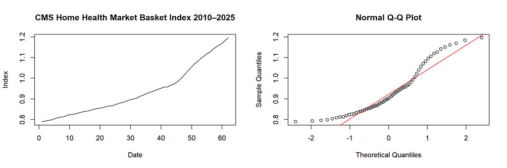

```r
par(mfrow = c(1, 2))
plot(TS_Data,
     main = "CMS Home Health Market Basket Index 2010–2025",
     xlab = "Date",
     ylab = "Index")

qqnorm(TS_Data)
qqline(TS_Data, col= "red")
```

The time series plot of the data indicates a clear upward trend with no apparent seasonal component or change in variance over time. The Q-Q plot shows that the CMS Home Health Market Basket data deviates from normality. Moreover, the Shapiro-Wilk test is performed to test the following hypothesis for normality.

$$H_0: \text{The CMS HH Market Basket Index follows a Normal Distribution} \\ \quad\text{vs.} \\ \quad H_1: \text{The CMS HH Market Basket Index does NOT follow a Normal Distribution}$$

```r
tidy(shapiro.test(TS_Data))
```

```
# A tibble: 1 × 3
  statistic  p.value method
      <dbl>    <dbl> <chr>
1     0.903 0.000137 Shapiro-Wilk normality test
```

*p*-value < 0.05, thus we can reject the null hypothesis. We have sufficient evidence to conclude that the CMS Home Health Market Basket Data does not follow a normal distribution.

### Stationarity Test and Model Specification

ADF test is performed to test stationarity:

$$H_0: \text{The CMS HH Market Basket Index is NOT stationary} \\ \quad\text{vs.} \\ \quad H_1: \text{The CMS HH Market Basket Index is stationary}$$

```r
adf.test(TS_Data)
```

```
    Augmented Dickey-Fuller Test

data:  TS_Data
Dickey-Fuller = -0.10276, Lag order = 3, p-value = 0.99
alternative hypothesis: stationary
```

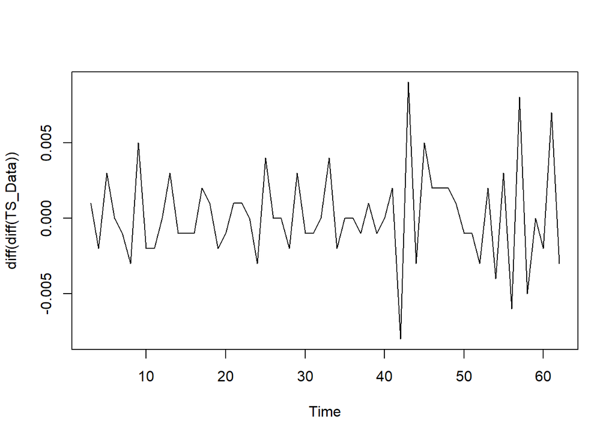

```r
plot(diff(diff(TS_Data)))
```

Since the *p*-value > 0.05, we fail to reject the null hypothesis. This indicates that the CMS HH Market Basket Index is non-stationary in its current form.

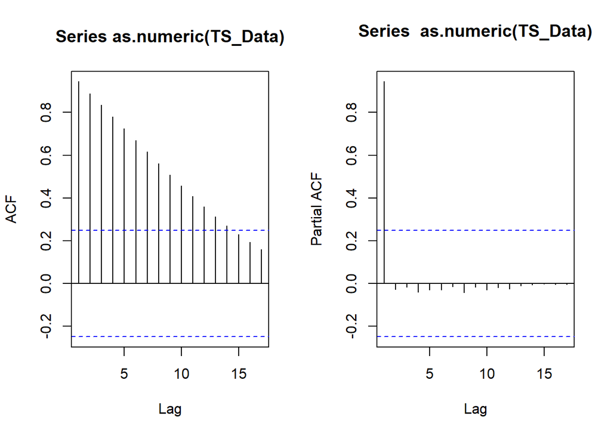

```r
par(mfrow = c(1,2))

acf(as.numeric(TS_Data))
pacf(as.numeric(TS_Data))
```

```r
eacf(as.numeric(TS_Data))
```

```
AR/MA
  0 1 2 3 4 5 6 7 8 9 10 11 12 13
0 x x x x x x x x x x x  x  x  o
1 x x x x o o o o o o o  o  o  o
2 x x x x o o o o o o o  x  o  o
3 o x o x o o o o o o o  o  o  o
4 o o o o o o o o o o o  o  o  o
5 x x o o o x o o o o o  o  o  o
6 x x x o o x o o o o o  o  o  o
7 x x o o o x o o o o o  o  o  o
```

```r
tidy(auto.arima(TS_Data))
```

```
# A tibble: 1 × 3
  term  estimate std.error
  <chr>    <dbl>     <dbl>
1 ar1     -0.584     0.104
```

The ARIMA(1,2,0) model was selected as the most appropriate specification based on the combined evidence from the ACF, PACF, and EACF diagnostics. The raw series exhibited a clear upward trend, and the slow decay in the ACF indicated non‑stationarity, supporting the need for differencing. The PACF showed a dominant spike at lag 1 with subsequent lags falling within the confidence bounds, consistent with an AR(1) structure.The auto.arima() function indicated a differencing of 2 and estimated co-efficent of -0.5844 using MLE. Together, these diagnostics pointed toward a parsimonious ARIMA(1,2,0) model that adequately captures the underlying dependence structure of the series.

**Candidate Model**: ARIMA (1,2,0) - First order autoregressive process with an integration of second order differencing.
$$(1 + 0.5844B)(1 - B)^2 Y_t = e_t$$

### Modeling and Results

```r
fit_ARIMA120 <- arima(
  TS_Data,
  order = c(1, 2, 0)
)

coeftest(fit_ARIMA120)
```

```
z test of coefficients:

    Estimate Std. Error z value  Pr(>|z|)
ar1 -0.58442    0.10359  -5.642 1.681e-08 ***
---
Signif. codes:  0 '***' 0.001 '**' 0.01 '*' 0.05 '.' 0.1 ' ' 1
```

```r
fit_ARIMA120_MLE <- arima(TS_Data, order = c(1, 2, 0), method = "ML")


fit_ARIMA120_CSS <- arima(TS_Data, order = c(1, 2, 0), method = "CSS")

model.comparison.arima <- matrix(NA, ncol = 4, nrow = 1)
colnames(model.comparison.arima) <- c("MLE_Est", "MLE_SE", "CSS_Est", "CSS_SE")
rownames(model.comparison.arima) <- c("phi")

model.comparison.arima[1, ] <- c(
  fit_ARIMA120_MLE$coef[1],
  sqrt(diag(fit_ARIMA120_MLE$var.coef))[1],
  fit_ARIMA120_CSS$coef[1],
  sqrt(diag(fit_ARIMA120_CSS$var.coef))[1]
)

knitr::kable(
  model.comparison.arima,
  digits = 4,
  caption = "Comparison of AR(1) Estimates and Standard Errors for MLE and CSS ARIMA(1,2,0) Models"
)
```

Comparison of AR(1) Estimates and Standard Errors for MLE and CSS ARIMA(1,2,0) Models

|  | MLE_Est | MLE_SE | CSS_Est | CSS_SE |
| --- | --- | --- | --- | --- |
| phi | -0.5844 | 0.1036 | -0.5932 | 0.1051 |

The ARIMA(1,2,0) model parameters were estimated using both Maximum Likelihood Estimation (MLE) and Conditional Sum of Squares (CSS) to assess the stability of the autoregressive parameter. Both estimation methods produced nearly identical AR(1) coefficients (–0.5844 for ML and –0.5932 for CSS), with MLE standard error being smaller. The auto.arima() function returned the ML estimate and The z‑test for the AR(1) parameter shows that the coefficient is highly statistically significant. This consistency across estimation methods strengthens confidence in the ARIMA(1,2,0) specification as an appropriate model for the data.

```
Null hypothesis: Residuals are iid noise.
Test                        Distribution Statistic   p-value
Ljung-Box Q                Q ~ chisq(20)     29.55    0.0774
McLeod-Li Q                Q ~ chisq(20)     23.44    0.2676
Turning points T     (T-40)/3.3 ~ N(0,1)        38    0.5409
Diff signs S       (S-30.5)/2.3 ~ N(0,1)        27    0.1266
Rank P           (P-945.5)/82.3 ~ N(0,1)       988    0.6056
```

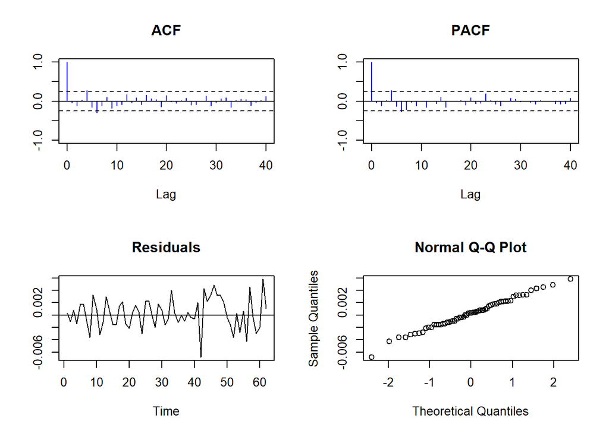

```r
res <- residuals(fit_ARIMA120)
test(res)
```

```r
shapiro.test(res)
```

```
    Shapiro-Wilk normality test

data:  res
W = 0.99261, p-value = 0.9721
```

$$H_0: \text{The Residuals are normal} \\ \quad\text{vs.} \\ \quad H_1: \text{The residuals are NOT normal}$$

All residual diagnostics support the adequacy of the ARIMA(1,2,0) model. The Ljung–Box test indicate no remaining autocorrelation. Nonparametric tests (turning points, difference signs, and rank tests) confirm that the residuals behave as iid noise.

The Shapiro–Wilk test shows no evidence against normality.The *p*-value > 0.5, so we fail to reject the null hypothesis, normality is not a concern for the candidate model.

Together, these results demonstrate that the ARIMA(1,2,0) model provides an appropriate fit for the CMS Home Health Market Basket Index.

```r
predict_ARIMA120=predict(fit_ARIMA120,n.ahead=8)
predict_ARIMA120$pred
```

```
Time Series:
Start = 63
End = 70
Frequency = 1
[1] 1.209753 1.222482 1.235809 1.248787 1.261969 1.275031 1.288164 1.301255
```

```r
predict_ARIMA120$se
```

```
Time Series:
Start = 63
End = 70
Frequency = 1
[1] 0.002484462 0.004305979 0.006905059 0.009679394 0.012854178 0.016263593
[7] 0.019958166 0.023881586
```

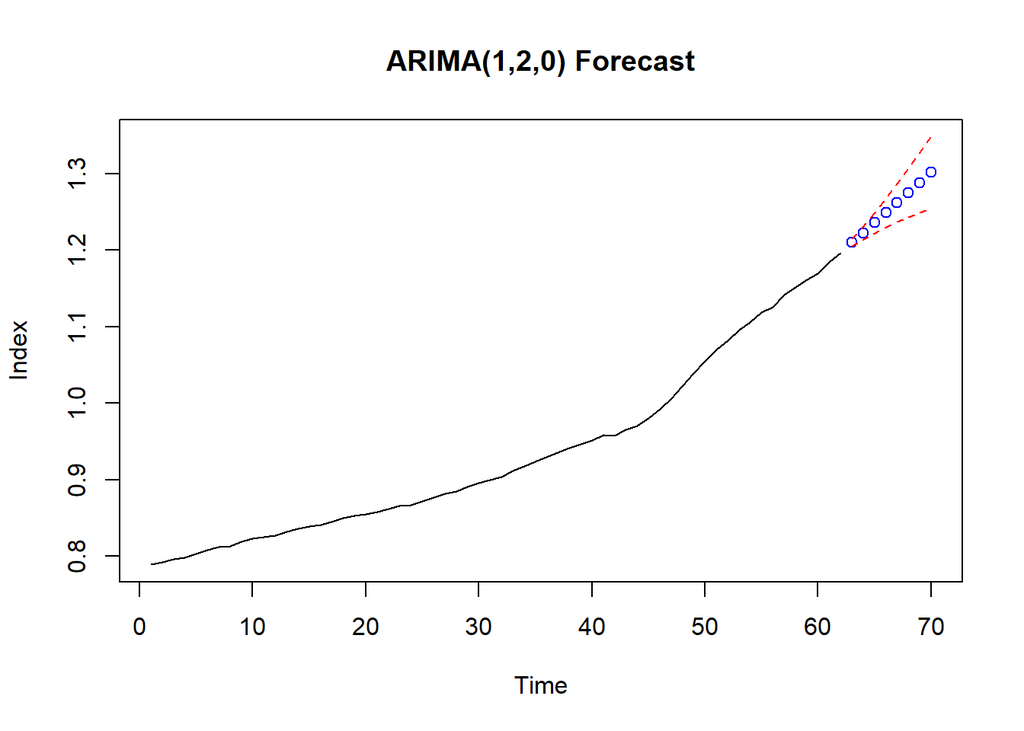

```r
upper_95 <- predict_ARIMA120$pred + 1.96 * predict_ARIMA120$se
lower_95 <- predict_ARIMA120$pred - 1.96 * predict_ARIMA120$se

plot(TS_Data, xlim = c(1, length(TS_Data) + 8),
     ylim = range(c(TS_Data, upper_95, lower_95)),
     main = "ARIMA(1,2,0) Forecast",
     ylab = "Index", xlab = "Time")

lines((length(TS_Data)+1):(length(TS_Data)+8), predict_ARIMA120$pred, col = "blue", type="b", pch=1)

lines((length(TS_Data)+1):(length(TS_Data)+8), upper_95, col = "red", lty = 2)
lines((length(TS_Data)+1):(length(TS_Data)+8), lower_95, col = "red", lty = 2)
```

```r
library(forecast)
library(knitr)

fitted_vals <- fitted(fit_ARIMA120)

accuracy_results <- data.frame(
  MAE  = mean(abs(residuals(fit_ARIMA120))),
  RMSE = sqrt(mean(residuals(fit_ARIMA120)^2)),
  MAPE = mean(abs(residuals(fit_ARIMA120) / TS_Data)) * 100,
  MSE  = mean(residuals(fit_ARIMA120)^2)
)


kable(
  accuracy_results,
  digits = 4,
  caption = "In-Sample Forecast Accuracy Metrics for ARIMA(1,2,0) Model"
)
```

In-Sample Forecast Accuracy Metrics for ARIMA(1,2,0) Model

| MAE | RMSE | MAPE | MSE |
| --- | --- | --- | --- |
| 0.002 | 0.0024 | 0.2078 | 0 |

The ARIMA(1,2,0) model demonstrated excellent in-sample forecasting performance across all evaluation metrics. The mean absolute error (MAE=0.002) and the root mean squared error (RMSE = 0.0024), indicate that prediction errors are minimal and consistent. Additonally, the mean absolute percentage error (MAPE=0.2078%) suggesting that the forecast deviates from actual values by less than 1% on average, reflecting a very high level of accuracy. Overall, these results indicate that the model captures the underlying patterns in the data effectively.

### Conclusion

This study applied a classical time‑series modeling framework to evaluate and forecast the CMS Home Health Market Basket Index, a key economic indicator used to adjust Medicare reimbursement rates. After exploring the structure of the series, the ACF, PACF, and EACF diagnostics consistently indicated the presence of a strong deterministic trend and supported the need for second‑order differencing. Model identification procedures converged on an ARIMA(1,2,0) specification, which was subsequently estimated using maximum likelihood. The autoregressive parameter was statistically significant and stable across estimation methods. Comprehensive residual diagnostics including tests for autocorrelation, normality, and randomness confirmed that the residuals behaved as white noise, indicating that the model adequately captured the underlying dynamics of the series. Forecast accuracy metrics (MAE, RMSE, MAPE, MSE) further supported the model’s suitability by showing that the in sample errors were small and consistent with a well‑fitting ARIMA process. Taken together, these results validate the ARIMA(1,2,0) model as an appropriate and reliable tool for short‑term forecasting of the Home Health Market Basket Index, providing a sound basis for anticipating future cost‑inflation adjustments within the home health sector.

## References

Berndt, Ernst R, David M Cutler, Richard G Frank, Zvi Griliches, Joseph P Newhouse, and Jack E Triplett. 2000. “Medical Care Prices and Output.” In *Handbook of Health Economics*, 1:119–80. Elsevier.

Centers for Medicare & Medicaid Services. 2025. “Medicare and Medicaid Programs: Calendar Year 2026 Home Health Prospective Payment System Rate Update and Policy Changes.” https://www.cms.gov/medicare/payment/prospective-payment-systems/home-health.

Cryer, Jonathan D., and Kung-Sik Chan. 2010. *Time Series Analysis: With Applications in r*. 2nd ed. New York: Springer.

Dritsakis, Nikolaos, and Paraskevi Klazoglou. 2019. “TIME SERIES ANALYSIS USING ARIMA MODELS: AN APPROACH TO FORECASTING HEALTH EXPENDITURES IN USA.” *International Economics/Economia Internazionale* 72 (1).

Huang, Yihuai, Chao Xu, Mengzhong Ji, Wei Xiang, and Da He. 2020. “Medical Service Demand Forecasting Using a Hybrid Model Based on ARIMA and Self-Adaptive Filtering Method.” *BMC Medical Informatics and Decision Making* 20 (1): 237.

Soyiri, Ireneous N, and Daniel D Reidpath. 2013. “An Overview of Health Forecasting.” *Environmental Health and Preventive Medicine* 18 (1): 1–9.

Vafin, Aidar. 2020. “Forecasting Macroeconomic Indicators for Seven Major Economies Using the ARIMA Model.” *Sage Science Economic Reviews* 3 (1): 1–16.